# Learning objectives

Through completing this project I will have a better understanding of...

1. Identify key hyperparameters in neural networks and how they can impact model training and fit
2. Build, tune the parameters of, and apply feed-forward neural networks to data
3. Implement and explain each and every part of a standard fully-connected neural network and its operation including feed-forward propagation, backpropagation, and gradient descent.
4. Apply a standard neural network implementation and search the hyperparameter space for optimized application.
5. Develop a detailed understanding of the math and practical implementation considerations of neural networks, one of the most widely used machine learning tools.

# 1

## Get to know your networks

The goal of this exercise is to better understand some of the key parameters used in neural networks so that you can be better prepared to tune your model. We'll be using the example data and data generation function below throughout this exercise.

```python
import pandas as pd
import numpy as np
```

```python
# Data generation function to create a checkerboard-patterned dataset
def make_data_checkerboard(n, noise=0):
    n_samples = int(n/4)
    scale = 5
    shift = 2.5
    center = 0.5
    c1a = (np.random.rand(n_samples,2)-center)*scale + [-shift, shift]
    c1b = (np.random.rand(n_samples,2)-center)*scale + [shift, -shift]
    c0a = (np.random.rand(n_samples,2)-center)*scale + [shift, shift]
    c0b = (np.random.rand(n_samples,2)-center)*scale + [-shift, -shift]
    X = np.concatenate((c1a,c1b,c0a,c0b),axis=0)
    y = np.concatenate((np.ones(2*n_samples), np.zeros(2*n_samples)))
    # Randomly flips a fraction of the labels to add noise
    for i,value in enumerate(y):
        if np.random.rand() < noise:
            y[i] = 1-value
    return (X,y)

# Training datasets (we create 3 to use to average over model)
np.random.seed(88)
N = 3
X_train = []
y_train = []
for i in range(N):
    Xt,yt = make_data_checkerboard(500, noise=0.25)
    X_train.append(Xt)
    y_train.append(yt)

# Validation and test data
X_val,y_val = make_data_checkerboard(3000, noise=0.25)
X_test,y_test = make_data_checkerboard(3000, noise=0.25)

# For the final performance evaluation, train on all of the training and validation data:
X_train_plus_val = np.concatenate((X_train[0], X_train[1], X_train[2], X_val), axis=0)
y_train_plus_val = np.concatenate((y_train[0], y_train[1], y_train[2], y_val), axis=0)
```

The key parameters we want to explore the impact of are: learning rate, batch size, regularization coefficient, and the model architecture (number of layers and the number of nodes per layer). We'll explore each of these and determine an optimized configuration of the network for this problem. For all of the settings we'll explore, we'll assume the following default hyperparameters for the model (we'll use scikit learn's [`MLPClassifier`](https://scikit-learn.org/stable/modules/generated/sklearn.neural_network.MLPClassifier.html#sklearn.neural_network.MLPClassifier.score) as our neural network model):

- `learning_rate_init` = 0.03
- `hidden_layer_sizes` = (30,30) (two hidden layers, each with 30 nodes)
- `alpha` = 0 (regularization penalty)
- `solver` = 'sgd' (stochastic gradient descent optimizer)
- `tol` = 1e-5 (this sets the convergence tolerance)
- `early_stopping` = False (this prevents early stopping)
- `activation` = 'relu' (rectified linear unit)
- `n_iter_no_change` = 1000 (this prevents early stopping)
- `batch_size` = 50 (size of the minibatch for stochastic gradient descent)
- `max_iter` = 500 (maximum number of epochs, which is how many times each data point will be used, not the number of gradient steps)

You'll notice we're eliminating early stopping so that we train the network the same amount for each setting. This allows us to compare the operation of the neural network while holding that value constant. Typically the amount of training would be another parameter to analyze the performance of.

**(a)** Visualize the impact of different hyperparameter settings. Starting with the default settings above make the following changes (only change one hyperparameter at a time). For each setting plot the decision boundary on the training data (since there are 3 training sets provided, use the first one to train on):

1. Vary the architecture (`hidden_layer_sizes`) by changing the number of nodes per layer while keeping the number of layers constant 2: (2,2), (5,5), (30,30)
2. Vary the learning rate: 0.0001, 0.01, 1
3. Vary the regularization: 0, 1, 10
4. Vary the batch size: 5, 50, 500

As you're exploring these settings, visit this website, the Neural Network Playground, which will give you the chance to interactively explore the impact of each of these parameters not only on the mode output, but will also provide insight into a number of other important aspects of neural networks including: learning curves, batch size, and most importantly, the output of each intermediate neuron so that you can visualize the how neurons interact allowing you to combine them for more complex, nonlinear decision boundaries. As you're noting this, experiment by adding or removing hidden layers and neurons per layer. Vary the learning rate, regularization, and other settings.

```python
import matplotlib.pyplot as plt
from matplotlib.colors import ListedColormap
from sklearn.model_selection import train_test_split
from sklearn.preprocessing import StandardScaler
from sklearn.datasets import make_moons, make_circles, make_classification
from sklearn.neural_network import MLPClassifier
```

```python
# Create the list of parameters to loop through
node_list = [(2,2), (5,5), (30,30)]
lr_list = [.0001, .01, 1]
reg_list = [0, 1, 10]
batch_list = [5, 50, 500]


# Create a plot function to call as I loop through the models
def plot(X_train, y_train, model, i, title):
    X = X_train
    y = y_train
    X = StandardScaler().fit_transform(X)

    # Create decision boundry grid to map onto
    x_min, x_max = X[:, 0].min() - .5, X[:, 0].max() + .5
    y_min, y_max = X[:, 1].min() - .5, X[:, 1].max() + .5
    xx, yy = np.meshgrid(np.arange(x_min, x_max, .03),
                         np.arange(y_min, y_max, .03))

    # Plot the data set with colormap
    cm = plt.cm.RdBu
    cm_bright = ListedColormap(['#FF0000', '#0000FF'])
    ax = plt.subplot(4, 3, i)

    # Fit the model and make predictions, plot them onto the grapg
    model = model.fit(X, y)
    Z = model.predict_proba(np.c_[xx.ravel(), yy.ravel()])[:, 1]
    Z = Z.reshape(xx.shape)
    ax.contourf(xx, yy, Z, cmap=cm, alpha=.8)
    ax.scatter(X[:, 0], X[:, 1], c=y_train, cmap=cm_bright,
               edgecolors='k')

    # Set the chart formatting
    ax.set_xlim(xx.min(), xx.max())
    ax.set_ylim(yy.min(), yy.max())
    ax.set_xticks(())
    ax.set_yticks(())
    ax.set_title(title, fontsize = 13)
    #ax.legend(*scatter.legend_elements(), loc="lower left", title="Classes")
    ax.set_xlabel('x1', fontsize = 10)
    ax.set_ylabel('x2', fontsize = 10)
```

- `learning_rate_init` = 0.03
- `hidden_layer_sizes` = (30,30) (two hidden layers, each with 30 nodes)
- `alpha` = 0 (regularization penalty)
- `solver` = 'sgd' (stochastic gradient descent optimizer)
- `tol` = 1e-5 (this sets the convergence tolerance)
- `early_stopping` = False (this prevents early stopping)
- `activation` = 'relu' (rectified linear unit)
- `n_iter_no_change` = 1000 (this prevents early stopping)
- `batch_size` = 50 (size of the minibatch for stochastic gradient descent)
- `max_iter` = 500 (maximum number of epochs, which is how many times each data point will be used, not the number of gradient steps)

```python
#Aggregate models into one list
mlp_list = []

### Iterate through each paramer and append model to list
for node in node_list:
    mlp_list.append(MLPClassifier(learning_rate_init = 0.03, hidden_layer_sizes = node, alpha = 0, solver = 'sgd',
                                  tol = 1e-5, early_stopping = False, activation = 'relu', n_iter_no_change = 1000,
                                  batch_size = 50, max_iter = 500))
for lr in lr_list:
    mlp_list.append(MLPClassifier(learning_rate_init = lr, hidden_layer_sizes = (30, 30), alpha = 0, solver = 'sgd',
                                  tol = 1e-5, early_stopping = False, activation = 'relu', n_iter_no_change = 1000,
                                  batch_size = 50, max_iter = 500))
for reg in reg_list:
    mlp_list.append(MLPClassifier(learning_rate_init = 0.03, hidden_layer_sizes = (30, 30), alpha = reg, solver = 'sgd',
                                  tol = 1e-5, early_stopping = False, activation = 'relu', n_iter_no_change = 1000,
                                  batch_size = 50, max_iter = 500))

for batch in batch_list:
    mlp_list.append(MLPClassifier(learning_rate_init = 0.03, hidden_layer_sizes = (30, 30), alpha = 0, solver = 'sgd',
                                  tol = 1e-5, early_stopping = False, activation = 'relu', n_iter_no_change = 1000,
                                  batch_size = batch, max_iter = 500))
#
```

[figure not shown]

```python
# Hide warnings
def warn(*args, **kwargs):
    pass
import warnings
warnings.warn = warn

# Create parameters for sub plots
rows = 4
cols = 4
i = 1
fig, ax = plt.subplots(4, 3, figsize = (15,15))

#loop through model list created about and plot them
for index, model in enumerate(mlp_list):
    if i <= 3:
        #print(i, index)
        title = f'Nodes Per Layer: {node_list[index]}'
        plot(X_train[0], y_train[0], model, i, title)
        i += 1
    if (i > 3 and i <= 6):
        #print(i, index)
        title = f'Learning Rate: {lr_list[index-3]}'
        plot(X_train[0], y_train[0], model, i, title)
        i += 1
    if (i > 6 and i <= 9):
        #print(i, index)
        title = f'Regularization Coefficient: {reg_list[index-6]}'
        plot(X_train[0], y_train[0], model, i, title)
        i += 1
    if (i > 9 and i <= 12):
        #print(i, index)
        title = f'Batch Size: {batch_list[index-9]}'
        plot(X_train[0], y_train[0], model, i, title)
        i += 1
```

**(b)** Now with some insight into which settings may work better than others, let's more fully explore the performance of these different settings in the context of our validation dataset. Holding all else constant (with the default settings mentioned above), vary each of the following parameters as specified below. Train your algorithm on the training data, and evaluate the performance of your algorithm on the validation dataset (here, overall accuracy is a reasonable performance metric since the classes are balanced and we don't weight one type of error as more important than the other); therefore, use the `score` method of the `MLPClassifier` for this. Create plot of accuracy vs each parameter you vary (this will be three plots).

1. Vary learning rate logarithmically from $10^{-5}$ to $10^{0}$ with 20 steps
2. Vary the regularization parameter logarithmically from $10^{-8}$ to $10^2$ with 20 steps
3. Vary the batch size over the following values: $[1,3,5,10,20,50,100,250,500]$

For each of these cases:

- Since neural networks can be sensitive to initialization values, run each of the settings above 3 times, and report the average accuracy in your plots (do not report the individual accuracy).
- Based on the results report your optimal choices for each of these hyperparameters and why you selected them.
- Use the chosen hyperparameter values as the new default settings for section (c) and (d).

```python
# Create parameters for learning rate, regularization, and batch size
log_lrs = np.logspace(-5,0, 20)
log_reg_param = np.logspace(-8,2, 20)
batch_size = [1,3,5,10,20,50,100,250,500]

# Initialize empty lists to appends scores too
log_lr_list = []
reg_param_list = []
batchsize_list = []


# Loop through all the parameters we are testing, train a model and get a score to append to list
for lr in log_lrs:
    model = MLPClassifier(learning_rate_init = lr, hidden_layer_sizes = (30, 30), alpha = 0, solver = 'sgd',
                          tol = 1e-5, early_stopping = False, activation = 'relu', n_iter_no_change = 1000,
                          batch_size = 50, max_iter = 500)

    # Average the score on all three training sets
    score_list = []
    for index in range(0,3):
        model.fit(X_train[index], y_train[index])
        score_list.append(model.score(X_val,y_val))
    log_lr_list.append(sum(score_list)/len(score_list))

for reg in log_reg_param:
    model = MLPClassifier(learning_rate_init = .03, hidden_layer_sizes = (30, 30), alpha = reg, solver = 'sgd',
                          tol = 1e-5, early_stopping = False, activation = 'relu', n_iter_no_change = 1000,
                          batch_size = 50, max_iter = 500)

    # Average the score on all three training sets
    score_list = []
    for index in range(0,3):
        model.fit(X_train[index], y_train[index])
        score_list.append(model.score(X_val,y_val))
    reg_param_list.append(sum(score_list)/len(score_list))


for batch in batch_size:
    model = MLPClassifier(learning_rate_init = .03, hidden_layer_sizes = (30, 30), alpha = 0, solver = 'sgd',
                          tol = 1e-5, early_stopping = False, activation = 'relu', n_iter_no_change = 1000,
                          batch_size = batch, max_iter = 500)

    # Average the score on all three training sets
    score_list = []
    for index in range(0,3):
        model.fit(X_train[index], y_train[index])
        score_list.append(model.score(X_val,y_val))
    batchsize_list.append(sum(score_list)/len(score_list))
```

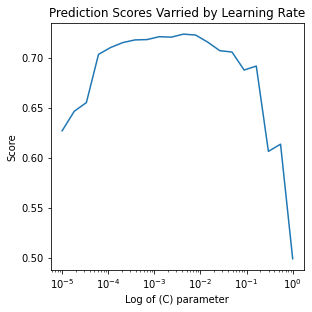

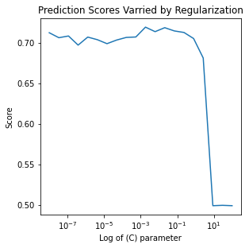

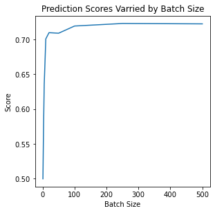

```python
plt.figure(figsize = (10,10))

# Plot learning rates
plt.subplot(2,2,1)
plt.plot(log_lrs, log_lr_list)
plt.xscale("log")
plt.title('Prediction Scores Varried by Learning Rate')
plt.xlabel('Log of (C) parameter')
plt.ylabel('Score')
plt.show()


# Plot Regulatization
plt.figure(figsize = (10,10))
plt.subplot(2,2,2)
plt.plot(log_reg_param, reg_param_list)
plt.xscale("log")
plt.title('Prediction Scores Varried by Regularization')
plt.xlabel('Log of (C) parameter')
plt.ylabel('Score')
plt.show()



# Plot batch size
plt.figure(figsize = (10,10))
plt.subplot(2,2,3)
plt.plot(batch_size, batchsize_list)
#plt.xscale("log")
plt.title('Prediction Scores Varried by Batch Size')
plt.xlabel('Batch Size')
plt.ylabel('Score')
plt.show()
```

```python
# Find the index of the best score value, and get corresponding score associated with them
lrmax = np.argsort(log_lr_list)[19]
lr_param = round(log_lrs[lrmax], 4)

regmax = np.argsort(reg_param_list)[19]
reg_param = round(log_reg_param[regmax], 4)

batchmax = np.argsort(batchsize_list)[8]
batch_param = batch_size[batchmax]

print(f'Optimal Hyperparameters- Learning Rate: {lr_param}, Regularization: {reg_param}, Batch size: {batch_param}')
```

```
Optimal Hyperparameters- Learning Rate: 0.0043, Regularization: 0.0018, Batch size: 250
```

The optimal hyperparameteres are:

- Learning Rate : 0.0043
- Regulatization : .0018
- Batch Size : 250

**(c)** Next we want to explore the impact of the model architecture but this means varying two parameters instead of one as above. To do this, evaluate the validation accuracy resulting from training the model using each pair of possible numbers of nodes per layer and number of layers from the lists below. We will assume that for any given configuration the number of nodes in each layer is the same (e.g. (2,2,2) and (25,25) are valid, but (2,5,3) is not). Use the optimized values for learning rate, regularization, and batch size selected from section (b).

- Number of nodes per layer: $[1,2,3,4,5,10,15,25,30]$
- Number of layers = $[1,2,3,4]$ As in part (b), repeat this evaluation 3 times once for each of the three training sets, and report the average accuracy in your plots across those three trials (do not report the individual accuracy). For plotting these results use heatmaps to plot the data in two dimensions. To make the heatmaps, you can use [this code on creating heatmaps] https://matplotlib.org/stable/gallery/images_contours_and_fields/image_annotated_heatmap.html). Be sure to include the numerical values of accuracy in each grid square as shown in the linked example and label your x, y, and color axes as always. For these numerical values, round them to **2 decimal places** (due to some randomness in the training process, any further precision is not typically meaningful).
- When you select your optimized parameters, be sure to keep in mind that these values may be sensitive to the data and may offer the potential to have high variance for larger models. Therefore, select the model with the highest accuracy but lowest number of total model weights.
- What do the results show? Which parameters did you select and why?

```python
nodes = [1,2,3,4,5,10,15,25,30]
layers = [1,2,3,4]
node_score_list = []
#hl_score_list = []

for node in nodes:
    hl_score_list = []
    for layer in layers:
        hidden = None
        if layer == 1:
            hidden = (node)
        if layer == 2:
            hidden = (node, node)
        if layer == 3:
            hidden = (node, node, node)
        if layer == 4:
            hidden = (node, node, node, node)
        model = MLPClassifier(learning_rate_init = .0043, hidden_layer_sizes = hidden, alpha = .0018, solver = 'sgd',
                          tol = 1e-5, early_stopping = False, activation = 'relu', n_iter_no_change = 1000,
                          batch_size = 250, max_iter = 500)
        score_list = []
        for index in range(0,3):
            model.fit(X_train[index], y_train[index])
            score_list.append(model.score(X_val,y_val))
        hl_score_list.append((sum(score_list)/len(score_list)))
        #print(f'h1 {hl_score_list}')
    node_score_list.append(hl_score_list)
    #print(f'node {node_score_list}')
```

```python
node_array = np.asarray(node_score_list)
node_array = node_array.round(2)
```

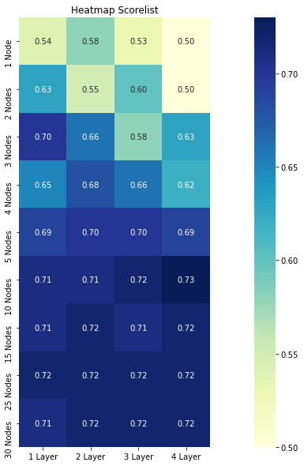

```python
import seaborn as sns

# Reformat the list of scores and put into dataframe
node_score_list = np.reshape(node_score_list, (4, 9))
df = pd.DataFrame(node_array)
df.column = ['1', '2', '3', '4']
df = df.rename({0:"1 Layer",1:"2 Layer", 2:"3 Layer", 3:"4 Layer",}, axis='columns')
df = df.rename({0:"1 Node",1:"2 Nodes", 2:"3 Nodes", 3:"4 Nodes", 4:"5 Nodes",5:"10 Nodes", 6:"15 Nodes", 7:"25 Nodes", 8:"30 Nodes"}, axis='index')

# Plot and the scores
plt.figure(figsize=(20, 10))
plt.title('Heatmap Scorelist')
plt.xlabel('Number of Layers')
plt.ylabel('Number of Nodes')
sns.heatmap(df, cmap="YlGnBu", annot=True, fmt=".2f", annot_kws={'size':10}, square=True)
```

**(d)** Based the optimal choice of hyperparameters and train your model with your optimized hyperparameters on all the training data (all three sets) AND the validation data (this is provided as `X_train_plus_val` and `y_train_plus_val`).

- Apply the trained model to the test data and report the accuracy of your final model on the test data.
- Plot an ROC curve of your performance (plot this with the curve in part (e) on the same set of axes if you complete that question).

```python
from sklearn.metrics import roc_curve, auc


# Initialize model with best parameters from parts B and C
modeld = MLPClassifier(learning_rate_init = lr_param, hidden_layer_sizes = (10, 10, 10, 10), alpha = reg_param, solver = 'sgd',
                          tol = 1e-5, early_stopping = False, activation = 'relu', n_iter_no_change = 1000,
                          batch_size = batch_param, max_iter = 500)

#Train and score model
modeld.fit(X_train_plus_val, y_train_plus_val)
print(f'The final accuracy of my model is {round(modeld.score(X_test, y_test),2)}')
```

```
The final accuracy of my model is 0.73
```

-Set the number of iterations to at least 25 (you'll look at 25 random pairings of possible parameters). You can go as high as you want, but it will take longer the larger this value is.

If you run this on Colab or any system with multiple cores, set the parameter n_jobs to -1 to use all available cores for more efficient training through parallelization

You'll need to set the range or distribution of the parameters you want to sample from. Search over the same ranges as in previous problems (except this time, you'll search over all the parameters at once). You can use lists of values for batch_size, loguniform for the learning rate and regularization parameter, and a list of tuples for the hidden_layer_sizes parameter.

Once the model is fit, use the best*params* attribute to extract the optimized values of the parameters

State the accuracy of the model on the test dataset

Plot the ROC curve corresponding to your best model through greedy hyperparameter section vs the model identified through random search. In the legend of the plot, report the AUC for each curve

Plot the final decision boundary for the greedy and random search-based classifiers along with one of the training datasets to demonstrate the shape of the final boundary

How did the performance compare?

```python
# Create a node and layer list that includes every combination to feed into the random search model
nodes = [1,2,3,4,5,10,15,25,30]
layers = [1,2,3,4]
node_score_list = []
#hl_score_list = []
hl_score_list = []
for node in nodes:
    # hl_score_list = []
    for layer in layers:
        hidden = None
        if layer == 1:
            hidden = (node)
        if layer == 2:
            hidden = (node, node)
        if layer == 3:
            hidden = (node, node, node)
        if layer == 4:
            hidden = (node, node, node, node)
        hl_score_list.append(hidden)
```

```python
from sklearn.linear_model import SGDClassifier
from sklearn.model_selection import GridSearchCV, RandomizedSearchCV
from time import time
import scipy.stats as stats
from sklearn.utils.fixes import loguniform


# Create MLP model with desired parameters, omitting the ones we will use random search to find
clf = MLPClassifier(solver = 'sgd', tol = 1e-5, early_stopping = False, activation = 'relu', n_iter_no_change = 1000,
                           max_iter = 500)

# A function to print results of random search
def report(results, n_top=3):
    for i in range(1, n_top + 1):
        candidates = np.flatnonzero(results['rank_test_score'] == i)
        for candidate in candidates:
            print("Model with rank: {0}".format(i))
            print("Mean validation score: {0:.3f} (std: {1:.3f})"
                  .format(results['mean_test_score'][candidate],
                          results['std_test_score'][candidate]))
            print("Parameters: {0}".format(results['params'][candidate]))
            print("")

# specify parameters and distributions to sample from
param_dist = {'learning_rate_init': loguniform(1e-5, 1e0),
              'alpha': loguniform(1e-8, 1e2),
              'hidden_layer_sizes':  [(2,2), (5,5), (20,20), (30,30)],
              'batch_size': list(range(1,500))}

# run randomized search
n_iter_search = 25
random_search = RandomizedSearchCV(clf, param_distributions=param_dist,
                                   n_iter=n_iter_search, verbose=1).fit(X_train_plus_val,y_train_plus_val)

# Time and output results of random search model
start = time()
random_search.fit(X_train_plus_val, y_train_plus_val)
print("RandomizedSearchCV took %.2f seconds for %d candidates"
      " parameter settings." % ((time() - start), n_iter_search))
report(random_search.cv_results_)
```

```
Fitting 5 folds for each of 25 candidates, totalling 125 fits
```

```
[Parallel(n_jobs=1)]: Using backend SequentialBackend with 1 concurrent workers.
[Parallel(n_jobs=1)]: Done 125 out of 125 | elapsed: 23.2min finished
```

```
Fitting 5 folds for each of 25 candidates, totalling 125 fits
```

```
[Parallel(n_jobs=1)]: Using backend SequentialBackend with 1 concurrent workers.
[Parallel(n_jobs=1)]: Done 125 out of 125 | elapsed: 10.1min finished
```

```
RandomizedSearchCV took 616.66 seconds for 25 candidates parameter settings.
Model with rank: 1
Mean validation score: 0.727 (std: 0.118)
Parameters: {'alpha': 1.7621565331655533e-07, 'batch_size': 117, 'hidden_layer_sizes': (5, 5), 'learning_rate_init': 0.013250026582359962}

Model with rank: 2
Mean validation score: 0.726 (std: 0.122)
Parameters: {'alpha': 0.2738765026000446, 'batch_size': 245, 'hidden_layer_sizes': (20, 20), 'learning_rate_init': 0.03890182490940563}

Model with rank: 3
Mean validation score: 0.722 (std: 0.112)
Parameters: {'alpha': 3.682940821720398e-05, 'batch_size': 58, 'hidden_layer_sizes': (20, 20), 'learning_rate_init': 0.0017023572117358936}
```

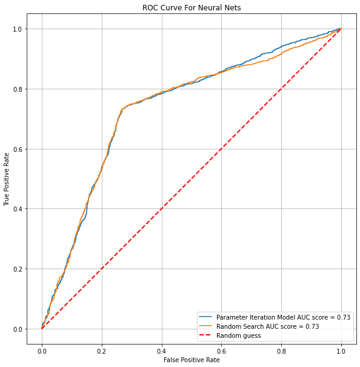

```python
from sklearn import metrics

# Create a model with optimal parameters from random search
randomMod =  MLPClassifier(learning_rate_init = 0.013250026582359962, alpha = 1.7621565331655533e-07, hidden_layer_sizes = (5, 5),
                           solver = 'sgd', tol = 1e-5, early_stopping = False, activation = 'relu', n_iter_no_change = 1000,
                           max_iter = 500)
randomMod.fit(X_train_plus_val, y_train_plus_val)

# Creacte ROC scores and thresholds
predictionsD = modeld.predict_proba(X_test)[:,1]
fprModD, tprModD, thresholdModD = roc_curve(y_test, modeld.predict_proba(X_test)[:,1])
auc_modD = metrics.roc_auc_score(y_test, predictionsD)

predictionsRand = randomMod.predict_proba(X_test)[:,1]
fprRand, tprRand, thresholdModD = roc_curve(y_test, randomMod.predict_proba(X_test)[:,1])
auc_modRand = metrics.roc_auc_score(y_test, predictionsRand)


# Plot ROC Scores
plt.figure(figsize = (10,10))

plt.plot(fprModD, tprModD,label = 'Parameter Iteration Model AUC score = %0.2f' % auc_modD)
plt.plot(fprRand, tprRand,label = 'Random Search AUC score = %0.2f' % auc_modRand)
plt.plot([0, 1], [0, 1], linestyle='--', lw=2, color='r', label='Random guess')

plt.legend(loc = 'lower right')
plt.title('ROC Curve For Neural Nets')
plt.xlabel('False Positive Rate')
plt.ylabel('True Positive Rate')
plt.grid('on')
plt.axis('square')



plt.show()
```

```python
randomMod.fit(X_train_plus_val, y_train_plus_val)
print(f'The final accuracy of my Random Search model is {round(randomMod.score(X_test, y_test),2)}')
```

```
The final accuracy of my Random Search model is 0.72
```

```python
# Create the list of parameters to loop through
model_list = []
model_list.append(randomMod)
model_list.append(modeld)

# Create a plot function to call for both models
def plot(X_train, y_train, model, i, title):
    X = X_train
    y = y_train
    X = StandardScaler().fit_transform(X)

    # Create decision boundry grid to map onto
    x_min, x_max = X[:, 0].min() - .5, X[:, 0].max() + .5
    y_min, y_max = X[:, 1].min() - .5, X[:, 1].max() + .5
    xx, yy = np.meshgrid(np.arange(x_min, x_max, .03),
                         np.arange(y_min, y_max, .03))

    # Plot the data set with colormap
    cm = plt.cm.RdBu
    cm_bright = ListedColormap(['#FF0000', '#0000FF'])
    ax = plt.subplot(4, 3, i)

    # Fit the model and make predictions, plot them onto the grapg
    model = model.fit(X, y)
    Z = model.predict_proba(np.c_[xx.ravel(), yy.ravel()])[:, 1]
    Z = Z.reshape(xx.shape)
    ax.contourf(xx, yy, Z, cmap=cm, alpha=.8)
    ax.scatter(X[:, 0], X[:, 1], c=y_train, cmap=cm_bright,
               edgecolors='k')

    # Set the chart formatting
    ax.set_xlim(xx.min(), xx.max())
    ax.set_ylim(yy.min(), yy.max())
    ax.set_xticks(())
    ax.set_yticks(())
    ax.set_title(title, fontsize = 13)
    #ax.legend(*scatter.legend_elements(), loc="lower left", title="Classes")
    ax.set_xlabel('x1', fontsize = 10)
    ax.set_ylabel('x2', fontsize = 10)
```

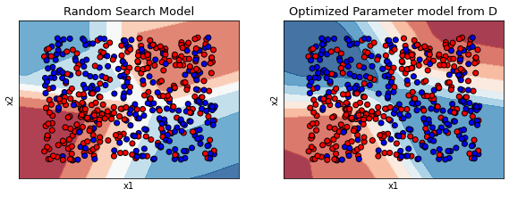

```python
# Hide warnings
def warn(*args, **kwargs):
    pass
import warnings
warnings.warn = warn

# Create parameters for sub plots
rows = 4
cols = 4
i = 1
fig, ax = plt.subplots(1,2, figsize = (15,15))

#loop through model list created about and plot them
for index, model in enumerate(model_list):
        if i == 1:
            title = f'Random Search Model'
        else:
            title = "Optimized Parameter model from D"
        plot(X_train[0], y_train[0], model, i, title)
        i += 1
```

This indicates that the random search arrived at similar results to our more iterative process of parameters. Had we employed a grid search, I suspect the results would have been the same, or marginially better by a negligable amount.